# Statistical Computing Final Project

Sammarieo Brown

2023-05-05

### Package Management -> Importing the necessary packages that will be used in this project

```r
suppressPackageStartupMessages({
  library(tibble)
  library(tidyr)
  library(haven)
  library(readr)
  library(dplyr)
  library(ggplot2)
  library(tidyverse)
  library(ggrepel)
  library(sjPlot)
  library(sjmisc)
  library(sjlabelled)
  library(corrplot)
  library(huxtable)
  library(rstatix)
  library(rempsyc)
  library(kableExtra)
  library(ggstatsplot)
  library(ggpubr)
  library(gtsummary)
  library(see)
  library(performance)
  library(cluster)
  library(Rtsne)
  library(factoextra)
  library(dendextend)
  library(tinytex)
  library(knitr)
  library(psych)
  library(gridExtra)


})
```

# Date Pre-processing & Preparation

1. Import dataset (SLC_2007.sav)
2. Rename column headers to be more descriptive.
3. convert the .sav file to a .csv file

```r
dataframe <- read_sav("F:/DataSpell/Statistical Computing Project/dataset/SLC_2007.sav")

# rename column names to a more descriptive column name

colnames(dataframe)[1:45] <- c("HH_Num", "Final_Weight", "Water_Bill", "HH_Size_All", "HH_Size_Mem", "Per_Cap_Con_All", "Per_Cap_Con_Mem", "Per_Cap_Pop_Quint", "Type_Dwelling", "Material_Walls", "Num_Rooms", "Type_Toilet", "Toilet_Shared", "Kitchen_Shared", "Own_Dwelling", "Other_Dwelling", "Renter", "Rent_Amt", "Rent_Period", "Rent_Helper", "Pay_Mortgage", "Mortgage_Payment", "Mortgage_Num", "Mortgage_Period", "Pay_Taxes", "Tax_Period", "Water_Source", "Water_Lock", "Water_Meter", "Water_Bill_Latest", "Water_Bill_Months", "Water_Source_Shared", "Water_Source_Dist", "Water_Source_Dist_Code", "Light_Source", "Electric_Bill", "Light_Bill_Months", "Own_Land_Tele", "Own_Cell_Tele", "Land_Tele_Bill", "Cell_Tele_Bill", "Land_Tele_Use", "Cell_Tele_Use", "Garbage_Dispose", "Area_Code")

# convert all the column names to lower case
colnames(dataframe) <- tolower(colnames(dataframe))

# coverting the SLC_2007.sav to csv

converted_df <- write.table(x=dataframe,file="F:/DataSpell/Statistical Computing Project/dataset/SLC_2007.csv", quote = FALSE, sep = ",")
```

## Data Wrangling

This process of the Data Science lifecycle involves cleaning, transforming and restructuring the raw data to make it suitable for analysis.

```r
# Set the seed and take 90% of the random sample

set.seed(710)

# import dataset
SLC_2007.Data <- read.csv("F:/DataSpell/Statistical Computing Project/dataset/SLC_2007.csv")


# random sample
n <- nrow(SLC_2007.Data)
sample_size <- round(0.9 * n) # calculate the desired sample size as 90% of the total number of rows

SLC_2007.Sample <- SLC_2007.Data[sample(seq_len(n), size = sample_size, replace = FALSE),] # take a random sample of the data set without replacement
```

```r
# create a sub dataset with the demographic variables
SLC_2007.Subset <- select(SLC_2007.Sample,
                          area_code,type_dwelling,
                          type_toilet,toilet_shared,kitchen_shared,own_dwelling,
                          water_source,hh_size_all,hh_size_mem,
                          per_cap_con_all,water_bill,water_source, water_bill_latest, water_source_shared,
                          water_meter


)
```

```r
# rename all the elements of the rows in our subset to labels.

SLC_2007.Subset <- SLC_2007.Subset %>%
  rename(
    area_code = area_code,
    type_dwelling = type_dwelling,
    type_toilet = type_toilet,
    toilet_shared = toilet_shared,
    kitchen_shared = kitchen_shared,
    own_dwelling = own_dwelling,
    water_source = water_source,
    water_source_shared = water_source_shared,
    water_meter = water_meter,

  ) %>%
  mutate(
    area_code = case_when(
      area_code == 1 ~ "KMA",
      area_code == 2 ~ "Other Town",
      area_code == 3 ~ "Rural",
      TRUE ~ as.character(area_code) # keep original value if not matched
    ),
    type_dwelling = case_when(
      type_dwelling == 1 ~ "SEPARATE HOUSE DETACHED",
      type_dwelling == 2 ~ "SEMI-DETACHED HOUSE",
      type_dwelling == 3 ~ "PARTS OF A HOUSE",
      type_dwelling == 4 ~ "APARTMENT BUILDING",
      type_dwelling == 5 ~ "TOWNHOUSE",
      type_dwelling == 6 ~ "IMPROVISED HOUSING UNIT",
      type_dwelling == 7 ~ "PARTS OF COMMERCIAL BUILDING",
      type_dwelling == 8 ~ "OTHER (SPECIFY)",
      TRUE ~ as.character(type_dwelling) # keep original value if not matched
    ),

    type_toilet = case_when(
      type_toilet == 1 ~ "W.C. LINKED TO SEWER",
      type_toilet == 2 ~ "W.C. NOT LINKED",
      type_toilet == 3 ~ "PIT",
      type_toilet == 4 ~ "OTHER",
      type_toilet == 5 ~ "NONE",
      TRUE ~ as.character(type_toilet) # keep original value if not matched
    ),
    toilet_shared = case_when(
      toilet_shared == 1 ~ "EXCLUSIVE USE",
      toilet_shared == 2 ~ "SHARED",
      TRUE ~ as.character(toilet_shared) # keep original value if not matched
    ),
    kitchen_shared = case_when(
      kitchen_shared == 1 ~ "EXCLUSIVE USE",
      kitchen_shared == 2 ~ "SHARED",
      kitchen_shared == 3 ~ "NONE",
      TRUE ~ as.character(kitchen_shared) # keep original value if not matched
    ),
    own_dwelling = case_when(
      own_dwelling == 1 ~ "YES",
      own_dwelling == 2 ~ "NO",
      TRUE ~ as.character(own_dwelling) # keep original value if not matched
    ),
    water_source = case_when(
      water_source == 1 ~ "Indoor tap/pipe",
      water_source == 2 ~ "Outside private",
      water_source == 3 ~ "Public standpipe",
      water_source == 4 ~ "Well",
      water_source == 5 ~ "River, Lake, Spring, Pond",
      water_source == 6 ~ "Rainwater (Tank)",
      water_source == 7 ~ "Trucked water (NWC)",
      water_source == 8 ~ "Bottled Water",
      water_source == 9 ~ "Other (Specify)",

      TRUE ~ as.character(water_source) # keep original value if not matched
    ),
    water_source_shared = case_when(
      water_source_shared == 1 ~ "YES",
      water_source_shared == 2 ~ "NO",
      TRUE ~ as.character(water_source_shared) # keep original value if not matched
    ),
    water_meter = case_when(
      water_meter == 1 ~ "Group",
      water_meter == 2 ~ "Individual",
      water_meter == 3 ~ "No Meter",
      TRUE ~ as.character(water_meter) # keep original value if not matched
    ),


  )
```

# Demographic Analysis

```r
SLC_2007.Subset2 <- SLC_2007.Subset %>%
        rename("Area Code" = area_code)

table1 <- SLC_2007.Subset2 %>%
        select("Area Code") %>%
        filter(!(`Area Code` %in% c(4, 5))) %>% # exclude Area Codes 4 and 5
        tbl_summary(
                missing = "no"
        ) %>%
        add_n() %>%
        modify_header(label = "**Characteristic**") %>%
        bold_labels()%>%
        as_kable_extra() %>% # Convert to kableExtra table
        kable_styling(latex_options = "hold_position", position = "center") # Center the table in the PDF output



table1
```

| Characteristic | N | N = 5,863 |
| --- | --- | --- |
| Area Code | 5,863 |  |
| KMA |  | 919 (16%) |
| Other Town |  | 1,208 (21%) |
| Rural |  | 3,736 (64%) |

<sup>1</sup> n (%)

```r
SLC_2007.Subset2 <- SLC_2007.Subset %>%
        rename("Type of Toilet" = type_toilet)
table2 <- SLC_2007.Subset2 %>%
        select("Type of Toilet") %>%
        tbl_summary(
                missing = "no"
        ) %>%
        add_n() %>% # add column with total number of non-missing observations
        modify_header(label = "**Characteristic**") %>% # update the column header
        bold_labels()%>%
        as_kable_extra() %>% # Convert to kableExtra table
        kable_styling(latex_options = "hold_position", position = "center") # Center the table in the PDF output




table2
```

| Characteristic | N | N = 6,278 |
| --- | --- | --- |
| Type of Toilet | 6,255 |  |
| NONE |  | 110 (1.8%) |
| OTHER |  | 7 (0.1%) |
| PIT |  | 2,931 (47%) |
| W.C. LINKED TO SEWER |  | 957 (15%) |
| W.C. NOT LINKED |  | 2,250 (36%) |

<sup>1</sup> n (%)

```r
# Load necessary libraries
library(dplyr)
library(gtsummary)

# Create a sub dataset with the demographic variables
SLC_2007.Subset_demographics <- select(SLC_2007.Subset,
                                       water_source_shared,
                                       kitchen_shared, toilet_shared, area_code)

# Prepare the dataset
SLC_2007.Demographics <- select(SLC_2007.Subset_demographics,
                                water_source_shared,
                                kitchen_shared, toilet_shared, area_code)


# Filter out area codes 4 and 5
SLC_2007.Demographics_filtered <- SLC_2007.Demographics %>%
  filter(area_code != 4 & area_code != 5)

# Create summary statistics table
summary_table <- SLC_2007.Demographics_filtered %>%
  tbl_summary(
    by = area_code,
    type = list(
      water_source_shared = "categorical",
      kitchen_shared = "categorical",
      toilet_shared = "categorical"
    ),
    statistic = list(
      water_source_shared ~ "{n} ({p}%)",
      kitchen_shared ~ "{n} ({p}%)",
      toilet_shared ~ "{n} ({p}%)"
    ),
    missing = "no",
    label = list(
      area_code ~ "Area Code",
      water_source_shared ~ "Water Source Shared",
      kitchen_shared ~ "Kitchen Shared",
      toilet_shared ~ "Toilet Shared"
    )
  )

# Display the result
summary_table
```

| **Characteristic** | **KMA**, N = 919<sup>1</sup> | **Other Town**, N = 1,208<sup>1</sup> | **Rural**, N = 3,736<sup>1</sup> |
| --- | --- | --- | --- |
| Water Source Shared |  |  |  |
| NO | 45 (73%) | 160 (86%) | 1,076 (91%) |
| YES | 17 (27%) | 27 (14%) | 106 (9.0%) |
| Kitchen Shared |  |  |  |
| EXCLUSIVE USE | 641 (70%) | 980 (81%) | 3,141 (84%) |
| NONE | 88 (9.6%) | 113 (9.4%) | 367 (9.9%) |
| SHARED | 187 (20%) | 110 (9.1%) | 212 (5.7%) |
| Toilet Shared |  |  |  |
| EXCLUSIVE USE | 586 (64%) | 912 (77%) | 3,017 (83%) |
| SHARED | 324 (36%) | 266 (23%) | 604 (17%) |

<sup>1</sup> n (%)

```r
SLC_2007.Subset2 <- SLC_2007.Subset %>%
  rename("Area Code" = area_code)

table3 <- SLC_2007.Subset2 %>%
  select("Area Code", per_cap_con_all) %>%
  filter(!(`Area Code` %in% c(4, 5))) %>% # exclude Area Codes 4 and 5
  group_by(`Area Code`) %>%
  tbl_summary(
    by = `Area Code`,
    type = all_continuous() ~ "continuous2",
    statistic = list(all_continuous() ~ c("{mean}", "{sd}")),
    digits = all_continuous() ~ c(2, 2),
    missing = "no"
  ) %>%
  add_n() %>%
  modify_header(label = "**Characteristic**") %>%
  bold_labels()%>%
  as_kable_extra() %>% # Convert to kableExtra table
  kable_styling( position = "center") # Center the table in the PDF output


table3
```

| Characteristic | N | KMA, N = 919 | Other Town, N = 1,208 | Rural, N = 3,736 |
| --- | --- | --- | --- | --- |
| per_cap_con_all | 5,863 |  |  |  |
| Mean |  | 131,854.05 | 105,834.19 | 76,277.71 |
| SD |  | 137,062.67 | 110,473.95 | 91,693.03 |

# Key Variable Analysis

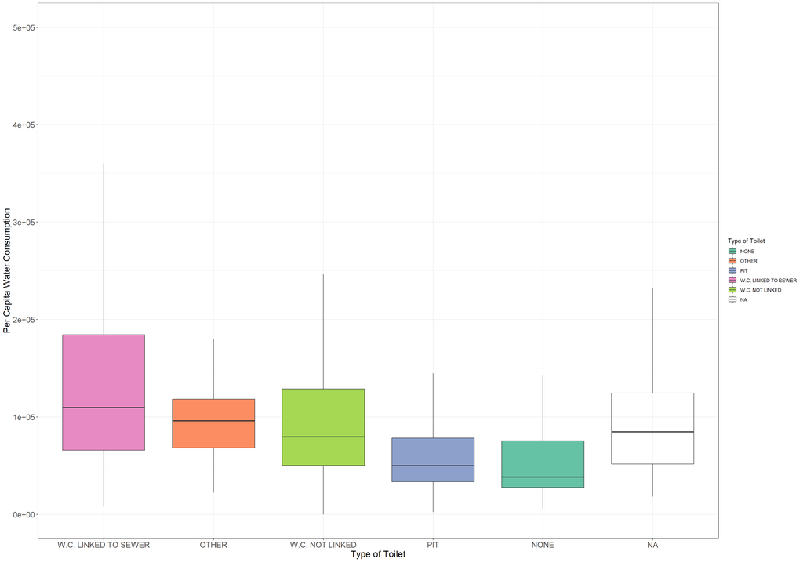

```r
SLC_2007.Subset2 <- SLC_2007.Subset %>%
  rename("Type of Toilet" = type_toilet)

# Calculate median per capita water consumption for each Type of Toilet
medians <- SLC_2007.Subset2 %>%
  group_by(`Type of Toilet`) %>%
  summarise(Median = median(per_cap_con_all, na.rm = TRUE))

# Merge calculated medians back into the main data frame
SLC_2007.Subset2 <- SLC_2007.Subset2 %>%
  left_join(medians, by = "Type of Toilet")

# Create a boxplot with reordered Type of Toilet on the x-axis
boxplot_colored_labeled_sorted <- ggplot(SLC_2007.Subset2, aes(x = reorder(`Type of Toilet`, -Median), y = per_cap_con_all, fill = `Type of Toilet`)) +
  geom_boxplot(outlier.shape = NA, coef = 1.5) + # Remove outliers by setting outlier.shape to NA and coef to 1.5
  coord_cartesian(ylim = c(0, 5e+05)) + # Set y-axis limits to 0 and 5e+05
  scale_fill_brewer(palette = "Set2") + # Apply a color theme from the ColorBrewer palette
  theme_bw() + # Use a black and white theme for the plot
  labs(
    x = "Type of Toilet",
    y = "Per Capita Water Consumption") +
  theme(axis.text = element_text(size = 14), # Increase the font size of the axis text to 14
        axis.title = element_text(size = 16)) # Increase the font size of the axis titles to 16

# Print the sorted boxplot
boxplot_colored_labeled_sorted
```

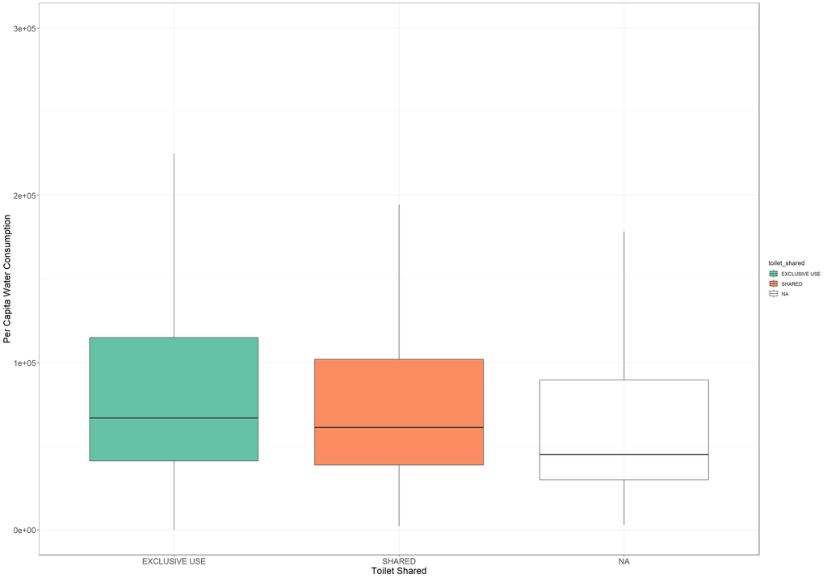

```r
# Create a boxplot of toilet_shared and per_cap_con_all
boxplot_colored <- ggplot(SLC_2007.Subset, aes(x = toilet_shared, y = per_cap_con_all, fill = toilet_shared)) +
  geom_boxplot(outlier.shape = NA, coef = 1.5) + # Remove outliers by setting outlier.shape to NA and coef to 1.5
  coord_cartesian(ylim = c(0, 3e+05)) + # Set y-axis limits to 0 and 5e+05
  scale_fill_brewer(palette = "Set2") + # Apply a color theme from the ColorBrewer palette
  theme_bw() + # Use a black and white theme for the plot
  labs(
    x = "Toilet Shared",
    y = "Per Capita Water Consumption") +
  theme(axis.text = element_text(size = 14), # Increase the font size of the axis text to 14
        axis.title = element_text(size = 16)) # Increase the font size of the axis titles to 16

# Print the boxplot
boxplot_colored
```

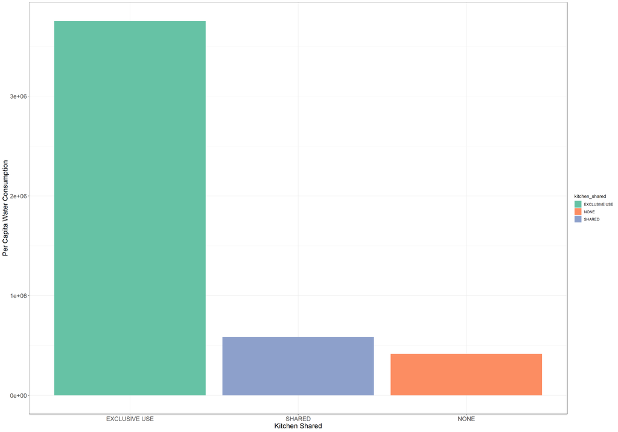

```r
# Calculate the percentages for each kitchen_shared category, removing NA values
SLC_2007.Subset4 <- SLC_2007.Subset %>%
  filter(!is.na(kitchen_shared)) %>%
  select(kitchen_shared, per_cap_con_all) %>% # Include 'per_cap_con_all' in the dataframe
  count(kitchen_shared, per_cap_con_all) %>% # Add 'per_cap_con_all' in the count function
  mutate(percentage = n / sum(n) * 100) %>%
  arrange(desc(percentage))

# Create a bar chart of kitchen_shared and per_cap_con_all, with percentage labels
bar_chart_colored <- ggplot(SLC_2007.Subset4, aes(x = reorder(kitchen_shared, -per_cap_con_all), y = per_cap_con_all, fill = kitchen_shared)) +
  geom_bar(stat = "identity", position = position_dodge(width = 0.9)) + # Use the identity statistic to plot the actual values and add position dodge
  scale_fill_brewer(palette = "Set2") + # Apply a color theme from the ColorBrewer palette
  theme_bw() + # Use a black and white theme for the plot
  labs(
    x = "Kitchen Shared",
    y = "Per Capita Water Consumption") +
  theme(axis.text = element_text(size = 14), # Increase the font size of the axis text to 14
        axis.title = element_text(size = 16)) # Increase the font size of the axis titles to 16

# Print the bar chart
bar_chart_colored
```

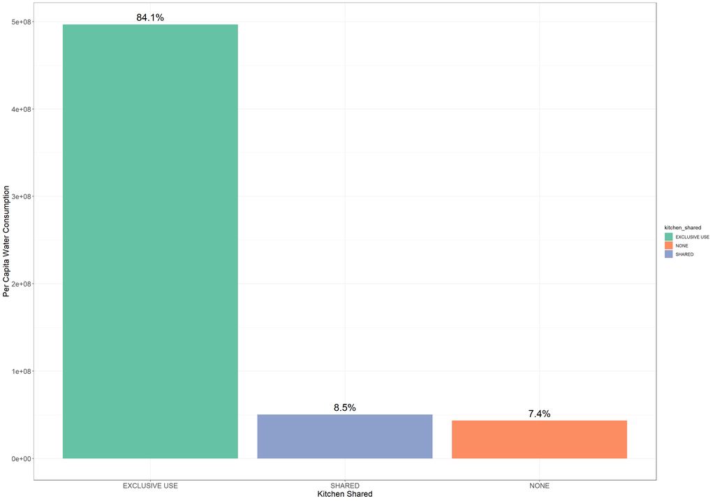

```r
# Calculate the total per capita water consumption for each kitchen_shared category, removing NA values
SLC_2007.Subset4 <- SLC_2007.Subset %>%
  filter(!is.na(kitchen_shared)) %>%
  select(kitchen_shared, per_cap_con_all) %>%
  group_by(kitchen_shared) %>%
  summarise(total_per_cap_con_all = sum(per_cap_con_all, na.rm = TRUE))

# Calculate the percentage of per capita water consumption for each kitchen_shared category
SLC_2007.Subset4 <- SLC_2007.Subset4 %>%
  mutate(percentage = total_per_cap_con_all / sum(total_per_cap_con_all))

# Create a bar chart of kitchen_shared and per_cap_con_all, with percentage labels
bar_chart_colored <- ggplot(SLC_2007.Subset4, aes(x = reorder(kitchen_shared, -total_per_cap_con_all), y = total_per_cap_con_all, fill = kitchen_shared)) +
  geom_bar(stat = "identity", position = position_dodge(width = 0.9)) +
  geom_text(aes(label = paste0(round(percentage * 100, 1), "%")), position = position_dodge(width = 0.9), vjust = -0.5, size = 7) +
  scale_fill_brewer(palette = "Set2") +
  theme_bw() +
  labs(
    x = "Kitchen Shared",
    y = "Per Capita Water Consumption") +
  theme(axis.text = element_text(size = 14),
        axis.title = element_text(size = 16))

# Print the bar chart
bar_chart_colored
```

```r
SLC_2007.Subset4 <- select(SLC_2007.Subset, area_code,kitchen_shared, per_cap_con_all,hh_size_all, )

SLC_2007.Subset4  <- SLC_2007.Subset4 %>%
  mutate(
    hh_size_all = case_when(
      hh_size_all == 1 ~ "1 person",
      hh_size_all == 2 ~ "2 person",
      hh_size_all == 3 ~ "3 person",
      hh_size_all >= 4 ~ "4 or more"
    )
  )


SLC_2007.Subset4  <- SLC_2007.Subset4 %>%
  filter(area_code != "Unknown")
```

```r
SLC_2007.Subset2 <- SLC_2007.Subset %>%
        rename("Type of Toilet" = type_toilet)

# Calculate summary statistics for each Type of Toilet
summary_table <- SLC_2007.Subset2 %>%
        group_by(toilet_shared) %>%
        summarise(
                Count = n(),
                Min = min(per_cap_con_all, na.rm = TRUE),
                Q1 = quantile(per_cap_con_all, 0.25, na.rm = TRUE),
                Median = median(per_cap_con_all, na.rm = TRUE),
                Mean = mean(per_cap_con_all, na.rm = TRUE),
                Q3 = quantile(per_cap_con_all, 0.75, na.rm = TRUE),
                Max = max(per_cap_con_all, na.rm = TRUE),
                SD = sd(per_cap_con_all, na.rm = TRUE)
        ) %>%
        as.data.frame()
```

# Inferential Analysis

## Goal 1: To determine if there is a difference in per capita water consumption based on location (area).

### Test: One-way ANOVA

```r
# Select the columns from your dataset
SLC_2007.Goal_1 <- select(SLC_2007.Subset, area_code, per_cap_con_all)
SLC_2007.Goal_1 <- SLC_2007.Goal_1 %>%
        mutate(area_code = recode(area_code,
                             `1` = "KMA",
                             `2` = "Other Town",
                             `3` = "Rural",

        )
        ) %>%
        filter(area_code != "4", area_code != "5")
```

## Check for Normality

Run the Linear Model

```r
aov.model.test <- lm(per_cap_con_all ~ area_code, data = SLC_2007.Goal_1)
```

## Normality by Groups

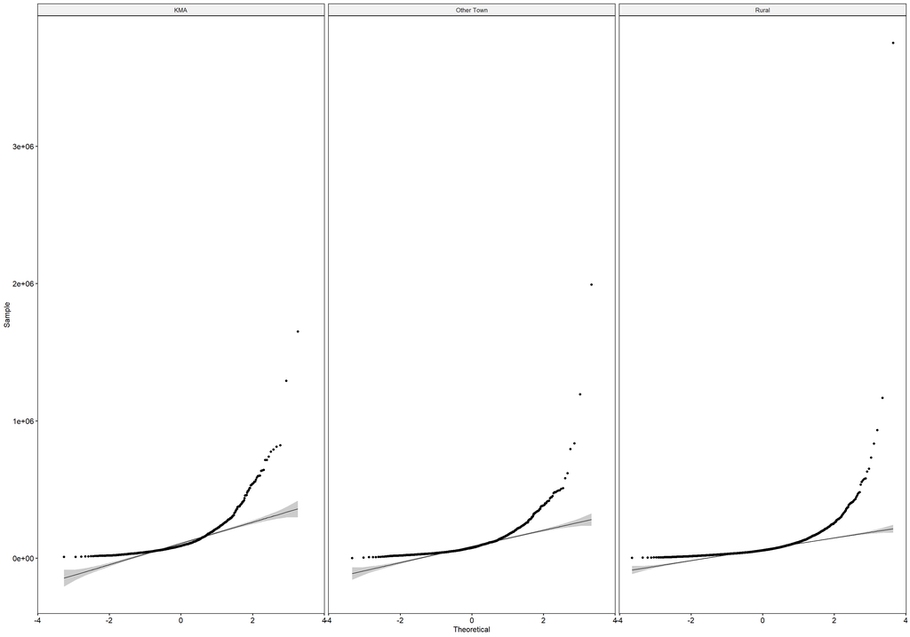

```r
# Check normality by groups, ignoring NA values
ggqqplot(na.omit(SLC_2007.Goal_1 ), "per_cap_con_all", facet.by = "area_code")
```

## Check for equal variance

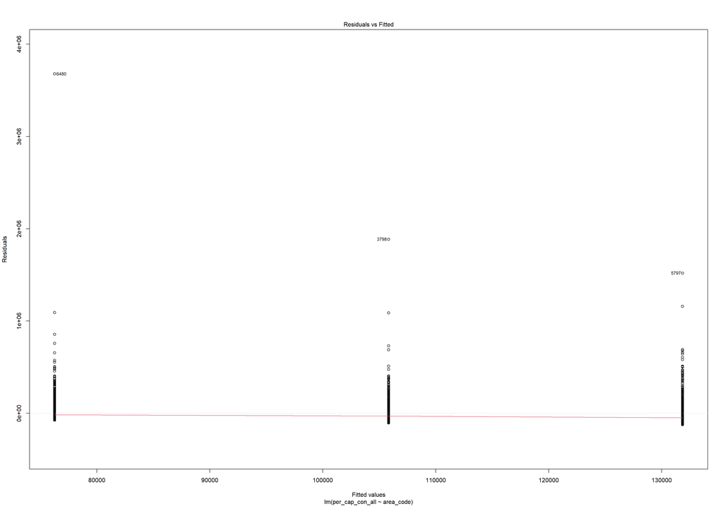

```r
plot(aov.model.test,1)
```

## One-Way ANOVA Test

```r
# One-Way ANOVA Test
# aov.test <- aov(per_cap_con_all ~ area_code, data = SLC_2007.Goal_1)
# summary(aov.test)
#
# # Calculate r^2
# RSq <- var(predict(aov.test)) / var(SLC_2007.Goal_1$per_cap_con_all, na.rm = TRUE)
# round(RSq, 4)
# One-Way ANOVA Test
aov.test <- aov(per_cap_con_all ~ area_code, data = SLC_2007.Goal_1)
aov.summary <- summary(aov.test)

# Calculate r^2
RSq <- var(predict(aov.test)) / var(SLC_2007.Goal_1$per_cap_con_all, na.rm = TRUE)
RSq <- round(RSq, 4)

# Extract data for the table
anova_table <- data.frame(
  Df = aov.summary[[1]][, "Df"],
  SumSq = aov.summary[[1]][, "Sum Sq"],
  MeanSq = aov.summary[[1]][, "Mean Sq"],
  FValue = aov.summary[[1]][, "F value"],
  Pr = aov.summary[[1]][, "Pr(>F)"]
)

# Add R-squared to the table
anova_table <- rbind(anova_table,
                     data.frame(Df = NA,
                                SumSq = NA,
                                MeanSq = NA,
                                FValue = NA,
                                Pr = RSq))


anova_table
```

| Df | SumSq | MeanSq | FValue | Pr |
| --- | --- | --- | --- | --- |
| 2 | 2.61e+12 | 1.3e+12 | 121 | 4.57e-52 |
| 5.86e+03 | 6.34e+13 | 1.08e+10 |  |  |
|  |  |  |  | 0.0395 |

## multiple comparisons test

```r
# pairwise.t.test(SLC_2007.Goal_1$per_cap_con_all, SLC_2007.Goal_1$area_code, p.adjust.method = "bonferroni")
# Perform the pairwise t-test
pairwise_test <- pairwise.t.test(SLC_2007.Goal_1$per_cap_con_all, SLC_2007.Goal_1$area_code, p.adjust.method = "bonferroni")

# Extract data for the table
pairwise_matrix <- pairwise_test$p.value
pairwise_values <- as.data.frame(pairwise_matrix)

# Create a new data frame to store the pairwise t-test results
pairwise_table <- data.frame(
  Comparison = rownames(pairwise_values),
  KMA = pairwise_values[, "KMA"],
  Other_Town = pairwise_values[, "Other Town"]
)

pairwise_table
```

| Comparison | KMA | Other_Town |
| --- | --- | --- |
| Other Town | 3.43e-08 |  |
| Rural | 1.93e-46 | 3.4e-17 |

## Comparison Plot

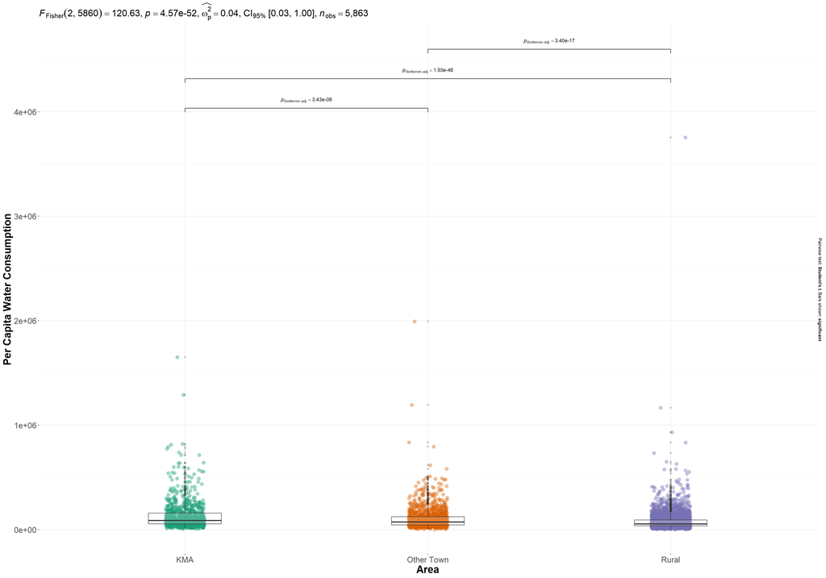

```r
# Create the plot using ggbetweenstats()
anova_plot <- ggbetweenstats(
  data = SLC_2007.Goal_1,
  x = area_code,
  y = per_cap_con_all,
  type = "parametric",
  var.equal = TRUE,
  plot.type = "box",
  pairwise.comparisons = TRUE,
  p.adjust.method = "bonferroni",
  pairwise.display = "significant",
  centrality.plotting = FALSE,
  bf.message = FALSE
)

# Modify y-axis title
anova_plot <- anova_plot +
  ylab("Per Capita Water Consumption") +
  xlab("Area")

# Customize the theme to enlarge elements
anova_plot <- anova_plot +
  theme(
    text = element_text(size = 16), # Increase base text size
    axis.title = element_text(size = 18), # Increase axis title size
    axis.text = element_text(size = 14), # Increase axis text size
    plot.title = element_text(size = 20, face = "bold"), # Increase plot title size
    strip.text = element_text(size = 16), # Increase facet label text size
    legend.text = element_text(size = 14), # Increase legend text size
    legend.title = element_text(size = 16), # Increase legend title size
    panel.spacing = unit(1, "lines") # Increase space between facets
  )

# Display the plot
anova_plot
```

## Goal 2: To determine if there is a difference in per capita water consumption based on whether toilet facilities are shared or not.

## Test: Independent Sample t-test

```r
# Prepare the dataset
SLC_2007.Goal_2 <- select(SLC_2007.Subset, toilet_shared, per_cap_con_all)
SLC_2007.Goal_2 <- SLC_2007.Goal_2 %>%
        mutate(toilet_shared = recode(toilet_shared,
                                      `1` = "EXCLUSIVE USE",
                                      `2` = "SHARED",

        )
        ) %>%
  filter(toilet_shared != "NA")

# Run the independent sample t-test
t_test_result <- SLC_2007.Goal_2 %>%
        filter(toilet_shared != "Unknown") %>% # Remove rows with "Unknown" values
        tbl_summary(
                by = toilet_shared,
                type = c(per_cap_con_all = "continuous"),
                statistic = list(per_cap_con_all ~ "{mean} ({sd})"),
                missing = "no",
                label = list(
                        per_cap_con_all ~ "Per Capita Water Consumption"
                )
        ) %>%
        add_difference()

# Display the result
t_test_result
```

| **Characteristic** | **EXCLUSIVE USE**, N = 4,880<sup>1</sup> | **SHARED**, N = 1,244<sup>1</sup> | **Difference**<sup>2</sup> | **95% CI**<sup>2,3</sup> | **p-value**<sup>2</sup> |
| --- | --- | --- | --- | --- | --- |
| Per Capita Water Consumption | 97,879 (115,289) | 83,389 (70,901) | 14,490 | 9,390, 19,590 | <0.001 |

<sup>1</sup> Mean (SD)  
<sup>2</sup> Welch Two Sample t-test  
<sup>3</sup> CI = Confidence Interval

## Independent Sample t-test

```r
# Run the independent sample t-test using Version 2
t_test_result_v2 <- nice_t_test(data = SLC_2007.Goal_2,
                                response = "per_cap_con_all",
                                group = "toilet_shared",
                                warning = FALSE) %>%
        nice_table()

# Display the result
t_test_result_v2
```

| Dependent Variable | t | df | p | d | 95% CI |
| --- | --- | --- | --- | --- | --- |
| per_cap_con_all | 5.57 | 3,121.95 | < .001 | 0.13 | [0.07, 0.20] |

## Goal 3:To determine if there is a relationship between per capita water consumption and household size (add control – area, toilet, kitchen)

#### Test: Multiple Linear Regression

```r
SLC_2007.Goal_3 <- select(SLC_2007.Subset, per_cap_con_all,hh_size_all,area_code,toilet_shared,kitchen_shared)
# recode variables.
SLC_2007.Goal_3 <- SLC_2007.Goal_3 %>%
        mutate(
                toilet_shared = recode(toilet_shared,
                                       `1` = "EXCLUSIVE USE",
                                       `2` = "SHARED"
                ),
                kitchen_shared = recode(kitchen_shared,
                                        `1` = "EXCLUSIVE USE",
                                        `2` = "SHARED",
                                        `3` = "NONE"
                ),
                area_code = recode(area_code,
                              `1` = "KMA",
                              `2` = "Other Town",
                              `3` = "Rural",

                ),
                hh_size_all = case_when(
                        hh_size_all == 1 ~ "1 person",
                        hh_size_all == 2 ~ "2 person",
                        hh_size_all == 3 ~ "3 person",
                        hh_size_all >= 4 ~ "4 or more"
                )
        )%>%
        filter(area_code != "4", area_code != "5",
               kitchen_shared != "NA",
               toilet_shared != "NA",

        )
```

## multiple linear regression model

```r
# Convert nominal variables to factors
SLC_2007.Goal_3_recoded <- SLC_2007.Goal_3 %>%
        mutate(
                toilet_shared = as.factor(toilet_shared),
                kitchen_shared = as.factor(kitchen_shared),
                area = as.factor(area_code),
                hh_size_all = as.factor(hh_size_all)

        )

# Run the multiple linear regression model
model <- lm(per_cap_con_all ~ hh_size_all + area_code + toilet_shared + kitchen_shared, data = SLC_2007.Goal_3)
tab_model(model)
```

|  | per_cap_con_all |  |  |
| --- | --- | --- | --- |
| Predictors | Estimates | CI | p |
| (Intercept) | 197755.96 | 189129.45 – 206382.47 | **<0.001** |
| hh size all [2 person] | -35544.51 | -43693.29 – -27395.73 | **<0.001** |
| hh size all [3 person] | -63484.62 | -71991.16 – -54978.08 | **<0.001** |
| hh size all [4 or more] | -89313.20 | -96073.49 – -82552.90 | **<0.001** |
| area code [Other Town] | -26864.13 | -35436.19 – -18292.07 | **<0.001** |
| area code [Rural] | -58285.36 | -65595.41 – -50975.30 | **<0.001** |
| toilet shared [SHARED] | -20724.74 | -28938.66 – -12510.82 | **<0.001** |
| kitchen shared [NONE] | -25857.20 | -35979.09 – -15735.31 | **<0.001** |
| kitchen shared [SHARED] | -11615.35 | -22932.87 – -297.84 | **0.044** |
| Observations | 5699 |  |  |
| R<sup>2</sup> / R<sup>2</sup> adjusted | 0.155 / 0.153 |  |  |

## Diagnostic Plots

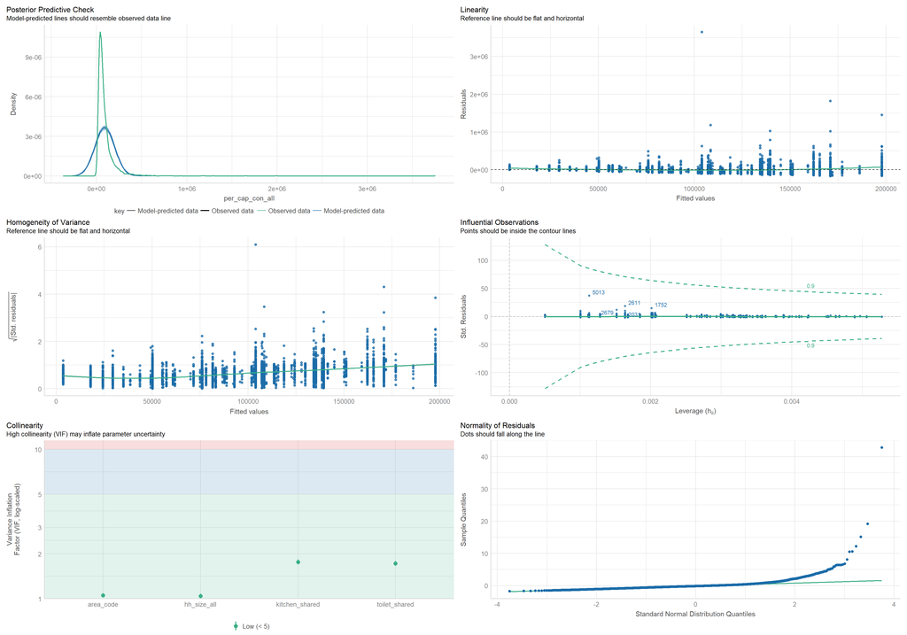

```r
# Diagnostic Plots

check_model(model)
```

# Advanced Data Analysis

```r
SLC_2007.Subset200 <- sample_n(SLC_2007.Subset, 200)

SLC_2007.Subset200 <- SLC_2007.Subset200 %>%
  filter(area_code != 4 & area_code != 5)
```

```r
SLC_2007.Subset200_filtered <- SLC_2007.Subset200 %>%
  select(area_code, per_cap_con_all,hh_size_all)

SLC_2007.Subset200_filtered  <- SLC_2007.Subset200_filtered  %>%
  mutate(
    hh_size_all = case_when(
      hh_size_all == 1 ~ "1 person",
      hh_size_all == 2 ~ "2 person",
      hh_size_all == 3 ~ "3 person",
      hh_size_all >= 4 ~ "4 or more"
    )
  )

SLC_2007.Subset200_filtered$area_code <- recode(SLC_2007.Subset200_filtered$area_code,
                                                "Rural" = 1,
                                                "KMA" = 2,
                                                "Other Town" = 3)

SLC_2007.Subset200_filtered$hh_size_all <- recode(SLC_2007.Subset200_filtered$hh_size_all,
                                                  "1 person" = 1,
                                                  "2 person" = 2,
                                                  "3 person"= 3,
                                                  "4 or more"= 4
)
```

## Create the dissimilarity matrix using Gower’s distance

```r
DistanceMatrix <- daisy(SLC_2007.Subset200_filtered, metric = "gower")
```

## Perform hierarchical clustering

```r
hc <- hclust(DistanceMatrix, method = "complete")
```

## Determine the optimal number of clusters

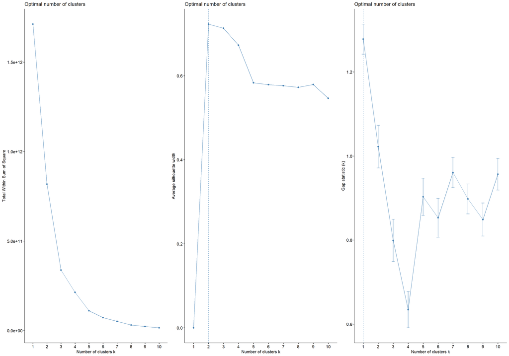

```r
library(factoextra)

plot1 <- fviz_nbclust(SLC_2007.Subset200_filtered, FUN = hcut, method = "wss")
plot2 <- fviz_nbclust(SLC_2007.Subset200_filtered, FUN = hcut, method = "silhouette")
gap_stat <- clusGap(SLC_2007.Subset200_filtered, FUN = hcut, nstart = 25, K.max = 10, B = 50)
plot3 <- fviz_gap_stat(gap_stat)

grid.arrange(plot1, plot2, plot3, ncol = 3)
```

```r
# 3 plots side by side
#ggarrange
```

## Visualize the dendrogram

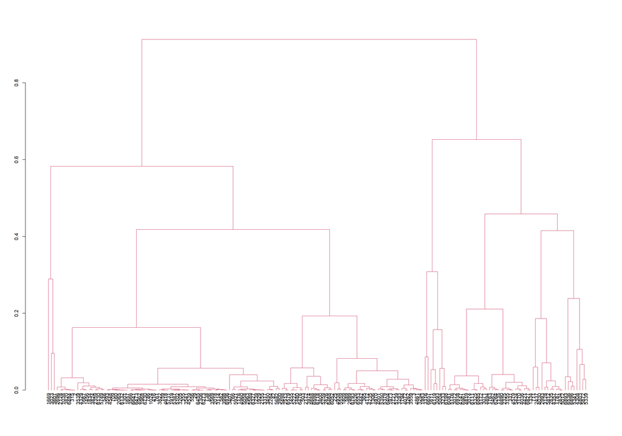

```r
dendrogram <- as.dendrogram(hc)
ColourDendrogram <- color_branches(dendrogram, h = 3)
plot(ColourDendrogram)
```

## Assign cluster labels to the observations

```r
clusterLabs <- cutree(hc, k = 2)  # Replace  with the optimal number of clusters found
SLC_2007.Subset200_clusters <- cbind(SLC_2007.Subset200_filtered, cluster = as.factor(clusterLabs))
```

## Visualize the clusters in a 2D plot

```r
fviz_cluster(list(data = SLC_2007.Subset200_filtered, cluster = clusterLabs))
```

[output not shown]

## Create a cluster summary

```r
cluster_summary <- SLC_2007.Subset200_clusters %>%
  group_by(cluster) %>%
  summarise(across(everything(), mean, na.rm = TRUE))
```

## Visualize the cluster summary

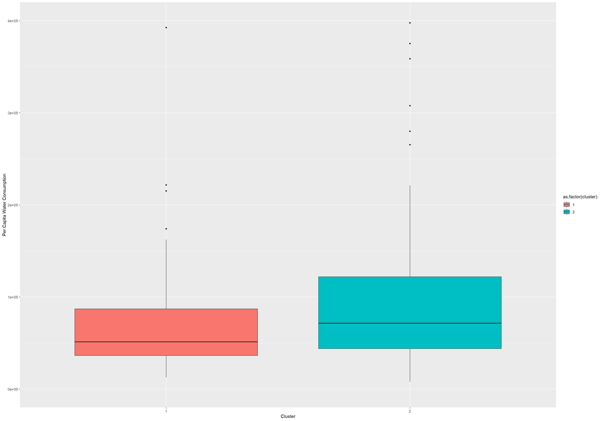

```r
ggplot(SLC_2007.Subset200_clusters, aes(x = as.factor(cluster), y = per_cap_con_all, fill = as.factor(cluster))) +
  geom_boxplot() +
  coord_cartesian(ylim = c(0, 4e+05)) +
  labs(x = "Cluster", y = "Per Capita Water Consumption")
```

```r
# Create a summary table for per capita water consumption by cluster
summary_table_boxplot <- SLC_2007.Subset200_clusters %>%
  mutate(cluster = as.factor(cluster)) %>%
  select(cluster, per_cap_con_all) %>%
  gtsummary::tbl_summary(by = cluster,
                         missing = "no",
                         type = list(per_cap_con_all = "continuous"),
                         statistic = list(per_cap_con_all = "{mean} ({sd}); Median: {median}; IQR: {p25}-{p75}"))

# Display the summary table
summary_table_boxplot
```

| **Characteristic** | **1**, N = 129<sup>1</sup> | **2**, N = 56<sup>1</sup> |
| --- | --- | --- |
| per_cap_con_all | 76,714 (96,799); Median: 51,374; IQR: 36,364-87,012 | 106,001 (93,351); Median: 71,505; IQR: 43,848-121,822 |

<sup>1</sup> Mean (SD); Median: Median; IQR: 25%-75%

```r
# Create a summary table
summary_table <- SLC_2007.Subset200_clusters %>%
  mutate(cluster = as.factor(cluster),
         area_code = recode(area_code,
                            "1" = "Rural",
                            "2" = "KMA",
                            "3" = "Other Town"),
         hh_size_all = recode(hh_size_all,
                              "1" = "1 person",
                              "2" = "2 person",
                              "3" = "3 person",
                              "4" = "4 or more")) %>%
  group_by(cluster) %>%
  select(cluster, area_code, hh_size_all, per_cap_con_all) %>%
  gtsummary::tbl_summary(by = cluster,
                         missing = "no",
                         type = list(area_code = "categorical",
                                     hh_size_all = "categorical",
                                     per_cap_con_all = "continuous"),
                         statistic = list(area_code = "{n} ({p}%)",
                                          hh_size_all = "{n} ({p}%)",
                                          per_cap_con_all = "{mean} ({sd})"))

# Display the summary table
summary_table
```

| **Characteristic** | **1**, N = 129<sup>1</sup> | **2**, N = 56<sup>1</sup> |
| --- | --- | --- |
| area_code |  |  |
| KMA | 0 (0%) | 28 (50%) |
| Other Town | 0 (0%) | 28 (50%) |
| Rural | 129 (100%) | 0 (0%) |
| hh_size_all |  |  |
| 1 person | 33 (26%) | 8 (14%) |
| 2 person | 19 (15%) | 7 (12%) |
| 3 person | 17 (13%) | 12 (21%) |
| 4 or more | 60 (47%) | 29 (52%) |
| per_cap_con_all | 76,714 (96,799) | 106,001 (93,351) |

<sup>1</sup> n (%); Mean (SD)

# Composite Index

## Recode the variables

```r
SLC_2007.Subset_Index <- SLC_2007.Subset %>%
  select(kitchen_shared,toilet_shared,water_source_shared,water_meter,per_cap_con_all,hh_size_all,water_bill)

# remove NAs
# SLC_2007.Subset_Index <- na.omit(SLC_2007.Subset_Index)


SLC_2007.Subset_Index <- SLC_2007.Subset_Index %>%
  mutate(
    kitchen_shared_recode = ifelse(kitchen_shared == "SHARED", 1, 0),
    toilet_shared_recode = ifelse(toilet_shared == "SHARED", 1, 0),
    water_source_shared_recode = ifelse(water_source_shared == "YES", 1, 0),
    water_meter_recode = ifelse(water_meter == "Group", 1, 0)
  )
```

## Calculate the sum of the recoded variables

```r
SLC_2007.Subset_Index <- SLC_2007.Subset_Index %>%
  mutate(shared_facilities_sum = kitchen_shared_recode +
    toilet_shared_recode +
    water_meter_recode
    # water_source_shared_recode
  )

# Calculate the highest possible score
highest_possible_score <- 3

# Normalize the sum to create the index
SLC_2007.Subset_Index <- SLC_2007.Subset_Index %>%
  mutate(shared_facilities_index = shared_facilities_sum / highest_possible_score)
```

## Cronbach Alpha analysis

```r
# List the names of the columns (variables) you will include in your index
Cron_Cols <- c("kitchen_shared_recode",
               "toilet_shared_recode",
               "water_meter_recode" )

# Create a subset of the data with only the selected columns
Cron_Data <- subset(SLC_2007.Subset_Index, select = Cron_Cols)


# Run the Cronbach Alpha analysis
Cron.Alpha <- psych::alpha(Cron_Data)
```

```r
alpha_table <- data.frame(
  raw_alpha = Cron.Alpha[["total"]][["raw_alpha"]],
  std_alpha = Cron.Alpha[["total"]][["std.alpha"]],
  G6_smc = Cron.Alpha[["total"]][["G6(smc)"]],
  average_r = Cron.Alpha[["total"]][["average_r"]],
  S_N = Cron.Alpha[["total"]][["S/N"]],
  ase = Cron.Alpha[["total"]][["ase"]],
  mean = Cron.Alpha[["total"]][["mean"]],
  sd = Cron.Alpha[["total"]][["sd"]],
  median_r = Cron.Alpha[["total"]][["median_r"]]
)


kable(alpha_table, digits = 2, caption = "Cronbach Alpha Table") %>%
  kable_styling(position = "center")
```

Cronbach Alpha Table

| raw_alpha | std_alpha | G6_smc | average_r | S_N | ase | mean | sd | median_r |
| --- | --- | --- | --- | --- | --- | --- | --- | --- |
| 0.59 | 0.62 | 0.55 | 0.35 | 1.65 | 0.01 | 0.16 | 0.29 | 0.28 |

```r
# Extract relevant information from the Cron.Alpha object
alpha_stats <- data.frame(
        items = rownames(Cron.Alpha$alpha.drop),
        raw_alpha = Cron.Alpha$alpha.drop[, "raw_alpha"],
        std_alpha = Cron.Alpha$alpha.drop[, "std.alpha"],
        G6_smc = Cron.Alpha$alpha.drop[, "G6(smc)"],
        mean = Cron.Alpha$item.stats[, "mean"],
        sd = Cron.Alpha$item.stats[, "sd"]
)

# Print overall alpha values
cat("Overall alpha values:\n")
```

```
## Overall alpha values:
```

```r
cat("Raw alpha:", Cron.Alpha$total$raw_alpha, "\n")
```

```
## Raw alpha: 0.5882944
```

```r
cat("Standardized alpha:", Cron.Alpha$total$std.alpha, "\n")
```

```
## Standardized alpha: 0.6224649
```

```r
cat("\n")
```

```r
# Formatting and printing the alpha_stats table
formatted_alpha_stats <- alpha_stats %>%
        kable(col.names = c("Items", "Raw Alpha", "Standardized Alpha", "G6 (smc)", "Mean", "SD"),
              caption = "Cronbach's Alpha Analysis", align = 'c', digits = 2)  %>%
        kable_styling(latex_options = "hold_position", position = "center") # Center the table in the PDF output

formatted_alpha_stats
```

Cronbach’s Alpha Analysis

| Items | Raw Alpha | Standardized Alpha | G6 (smc) | Mean | SD |
| --- | --- | --- | --- | --- | --- |
| kitchen_shared_recode | 0.44 | 0.44 | 0.28 | 0.09 | 0.28 |
| toilet_shared_recode | 0.36 | 0.40 | 0.25 | 0.20 | 0.40 |
| water_meter_recode | 0.67 | 0.70 | 0.54 | 0.27 | 0.44 |

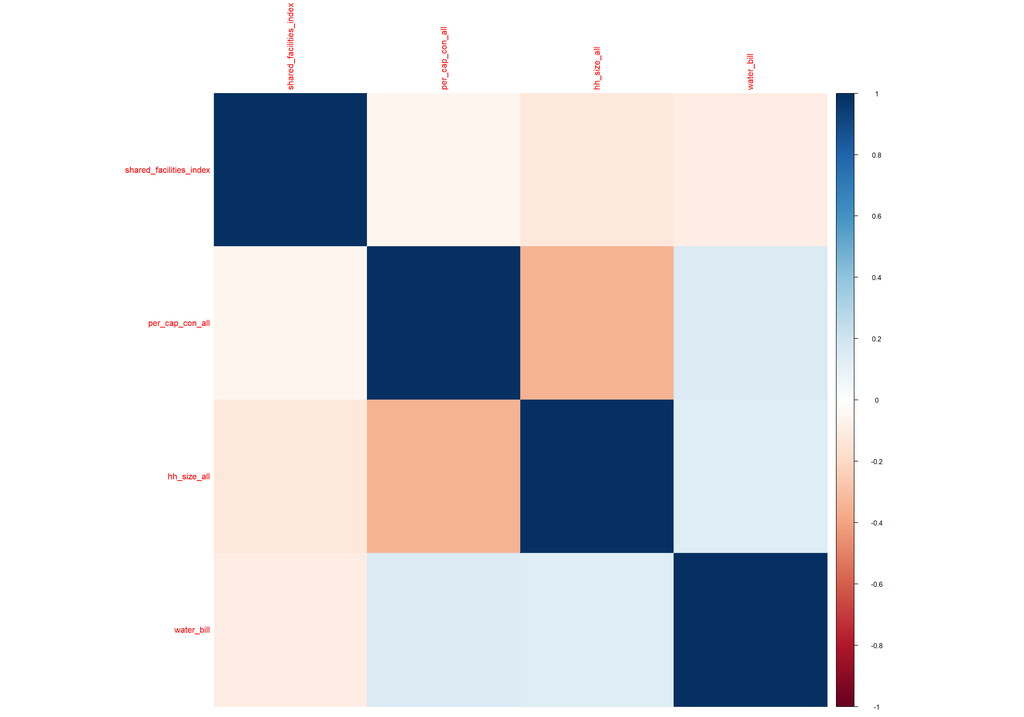

```r
# Check for missing values and handle them
correlation_data <- SLC_2007.Subset_Index %>%
  select(shared_facilities_index, per_cap_con_all, hh_size_all,water_bill) %>%
  na.omit()

# Ensure data types are numeric
correlation_data$hh_size_all <- as.numeric(correlation_data$hh_size_all)
correlation_data$per_cap_con_all <- as.numeric(correlation_data$per_cap_con_all)
correlation_data$water_bill <- as.numeric(correlation_data$water_bill)
# Calculate the correlation matrix
correlation_matrix <- cor(correlation_data)

# Create the correlation plot
corrplot(correlation_matrix, method = "color")
```

```r
# Convert the correlation matrix to a table
correlation_table <- kable(correlation_matrix, digits = 3, caption = "Correlation Matrix") %>%
  kable_styling(position = "center")

# Print the correlation table
correlation_table
```

Correlation Matrix

|  | shared_facilities_index | per_cap_con_all | hh_size_all | water_bill |
| --- | --- | --- | --- | --- |
| shared_facilities_index | 1.000 | -0.059 | -0.129 | -0.097 |
| per_cap_con_all | -0.059 | 1.000 | -0.350 | 0.151 |
| hh_size_all | -0.129 | -0.350 | 1.000 | 0.136 |
| water_bill | -0.097 | 0.151 | 0.136 | 1.000 |

```r
index_mean <- mean(SLC_2007.Subset_Index$shared_facilities_index)
index_median <- median(SLC_2007.Subset_Index$shared_facilities_index)
index_sd <- sd(SLC_2007.Subset_Index$shared_facilities_index)

cat("Mean shared facilities index:", round(index_mean, 2), "\n")
```

```
## Mean shared facilities index: NA
```

```r
cat("Median shared facilities index:", round(index_median, 2), "\n")
```

```
## Median shared facilities index: NA
```

```r
cat("Standard deviation of shared facilities index:", round(index_sd, 2), "\n")
```

```
## Standard deviation of shared facilities index: NA
```

# Inferential Analysis of Composite Index

## Goal 5 Is there a relationship between shared facilities index and per capita water consumption?

- Test: Simple Linear Regression

```r
indexModel <- lm(per_cap_con_all ~ shared_facilities_index, data = SLC_2007.Subset_Index)
tab_model(indexModel)
```

|  | per_cap_con_all |  |  |
| --- | --- | --- | --- |
| Predictors | Estimates | CI | p |
| (Intercept) | 119010.32 | 114456.71 – 123563.93 | **<0.001** |
| shared facilities index | -23283.57 | -36217.50 – -10349.64 | **<0.001** |
| Observations | 3496 |  |  |
| R<sup>2</sup> / R<sup>2</sup> adjusted | 0.004 / 0.003 |  |  |

## Diagnostic Plots

[figure not shown]

```r
# Diagnostic Plots

check_model(model)
```